# Hypothesis analysis only for control and experimental group (to achieve a balanced data set)

This notebook includes the statistical hypothesis tests excluding the context-free experimental group, since it has less test participants than the other two groups (N = 13 vs N = 21). This way, we can compare if the fact that the full dataset is unbalanced impacts the results of the hypothesis tests.

```r
library(WRS2)
library(rcompanion)
library(feather)
library(ggplot2)
library(ez)
library(schoRsch)
library(MASS)
library(car)
library(tidyverse)
library(here)
library(rstatix)
```

## Load the data

We are loading three versions of our dataframe. df_wide has one row per participant.

```r
df_wide <- read_feather(path = here('../../data_frames/results_test_18-03-2020.file'))
```

```
Coercing int64 to doubleCoercing int64 to doubleCoercing int64 to doubleCoercing int64 to doubleCoercing int64 to doubleCoercing int64 to doubleCoercing int64 to doubleCoercing int64 to doubleCoercing int64 to doubleCoercing int64 to doubleCoercing int64 to double
```

df_long has one row per trial per participant (so three rows per participant for interruption 1, 2, 3).

```r
df_long <- read_feather(path = here('../../data_frames/results_test_18-03-2020_messwdh.file'))
```

```
Coercing int64 to doubleCoercing int64 to doubleCoercing int64 to doubleCoercing int64 to double
```

df_nasa has four rows per particpant, one for each nasa-tlx test

```r
df_nasa <- read_feather(path = here('../../data_frames/results_test_18-03-2020_messwdh_nasa.file'))
```

```
Coercing int64 to doubleCoercing int64 to doubleCoercing int64 to doubleCoercing int64 to double
```

## Prepare the data

### Assign participants to the experimental group

- version 1 and 2 –> control group
- version 3 und 4 –> context-free experimental group
- version 5 und 6–> context-sensitive experimental group

```r
df_long$group <- ifelse((df_long$version == 5 | df_long$version == 6), 'context-sensitive experimental group', ifelse((df_long$version == 1 | df_long$version == 2), 'control group', 'context-free experimental group'))
df_nasa$group <- ifelse((df_nasa$version == 5 | df_nasa$version == 6), 'context-sensitive experimental group', ifelse((df_nasa$version == 1 | df_nasa$version == 2), 'control group', 'context-free experimental group'))
df_wide$group <- ifelse((df_wide$version == 5 | df_wide$version == 6), 'context-sensitive experimental group', ifelse((df_wide$version == 1 | df_wide$version == 2), 'control group', 'context-free experimental group'))
```

### Create balanced dataframe without the context-free experimental group

```r
df_long <- df_long[!(df_long$group=="context-free experimental group"),]
df_nasa <- df_nasa[!(df_nasa$group=="context-free experimental group"),]
df_wide <- df_wide[!(df_wide$group=="context-free experimental group"),]
```

## Testing Hypotheses

### Performance

The statistical analysis of the data revealed no significant effects for either of the performance measure, confirming the analysis which included the context-free experimental group.

#### Correct entries

There is no significant effect for the number of correct entries.

```r
mean_correct_entries <- tapply(df_wide$correct_entries_after_interruption, df_wide$group, mean)
mean_correct_entries
```

```
context-sensitive experimental group                        control group
                            8.333333                             8.285714
```

```r
aggregate( correct_entries_after_interruption ~ group, df_wide, sd )
```

| group | correct_entries_after_interruption |
| --- | --- |
| context-sensitive experimental group | 4.757450 |
| control group | 4.406165 |

Test requirements for t-test

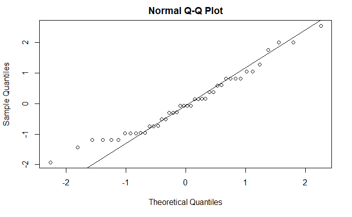

```r
## lineare model for correct_entries ~ groups
lm_cor_entries <- lm(df_wide$correct_entries_after_interruption~ df_wide$group)
# get studentized residuals
rstudent_cor_entries <- rstudent(lm_cor_entries)
qqnorm(rstudent_cor_entries); qqline(rstudent_cor_entries)
```

```r
# Run Shapiro-Wilk test
shapiro.test(x = rstudent_cor_entries )
```

```
    Shapiro-Wilk normality test

data:  rstudent_cor_entries
W = 0.96668, p-value = 0.2543
```

```r
## test homogenity of variances
var.test(correct_entries_after_interruption~group, conf.level=0.95, data = df_wide, alternative=c("two.sided", "less", "greater"))
```

```
    F test to compare two variances

data:  correct_entries_after_interruption by group
F = 1.1658, num df = 20, denom df = 20, p-value = 0.7349
alternative hypothesis: true ratio of variances is not equal to 1
95 percent confidence interval:
 0.4730435 2.8731160
sample estimates:
ratio of variances
          1.165808
```

The tests indicate that the data is normally distributed with equal variances. Thus, we compute a t-test.

```r
ttest_correct_entries <- t.test(df_wide$correct_entries_after_interruption~ df_wide$group)
ttest_correct_entries
```

```
    Welch Two Sample t-test

data:  df_wide$correct_entries_after_interruption by df_wide$group
t = 0.033653, df = 39.767, p-value = 0.9733
alternative hypothesis: true difference in means is not equal to 0
95 percent confidence interval:
 -2.812755  2.907993
sample estimates:
mean in group context-sensitive experimental group
                                          8.333333
                       mean in group control group
                                          8.285714
```

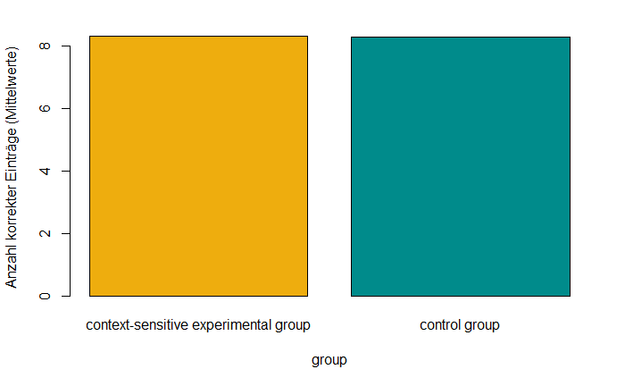

```r
# plot means between groups
barplot(mean_correct_entries, col = c('darkgoldenrod2', 'darkcyan'), xlab = 'group', ylab = 'Anzahl korrekter Einträge (Mittelwerte)')
```

```
`fun.y` is deprecated. Use `fun` instead.
```

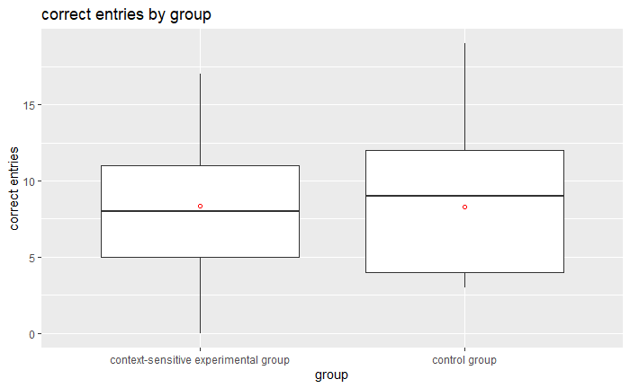

```r
# boxplots
ggplot(df_wide,aes(x = group, y= correct_entries_after_interruption) ) +
  geom_boxplot() +
  stat_summary(fun.y=mean,shape=1,col='red',geom='point') +
  labs(x="group",
       y = "correct entries",
       title="correct entries by group")
```

#### Mistakes

There are no significant effects for the number of mistakes.

```r
mean_errors <- tapply(df_wide$mistakes_after_interruption, df_wide$group, mean)
```

##### test requirements for t-test

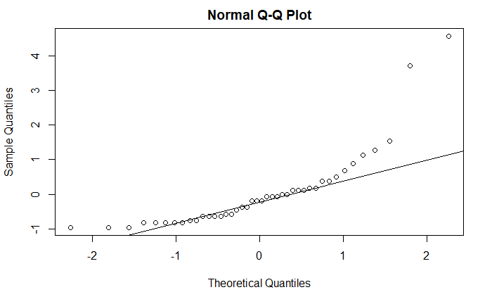

```r
lm_mistakes <- lm(df_wide$mistakes_after_interruption~ df_wide$group)
# get studentized residuals
rstudent_mistakes <- rstudent(lm_mistakes)
qqnorm(rstudent_mistakes); qqline(rstudent_mistakes)
```

```r
# Run Shapiro-Wilk test
shapiro.test(x = rstudent_mistakes )
```

```
    Shapiro-Wilk normality test

data:  rstudent_mistakes
W = 0.72875, p-value = 1.824e-07
```

```r
## test homogenity of variances
var.test(mistakes_after_interruption~group, conf.level=0.95, data = df_wide)
```

```
    F test to compare two variances

data:  mistakes_after_interruption by group
F = 0.86429, num df = 20, denom df = 20, p-value = 0.7475
alternative hypothesis: true ratio of variances is not equal to 1
95 percent confidence interval:
 0.3506968 2.1300213
sample estimates:
ratio of variances
         0.8642868
```

The QQplots indicate that the data is not normally distributed. Thus, we compute a Mann-Whitney-U-Test for two independent samples.

```r
# compare between groups
utest_mistakes <- wilcox.test(df_wide$mistakes_after_interruption~ df_wide$group, paired=FALSE, conf.int=FALSE)
```

```
kann bei Bindungen keinen exakten p-Wert Berechnen
```

```r
utest_mistakes
```

```
    Wilcoxon rank sum test with continuity correction

data:  df_wide$mistakes_after_interruption by df_wide$group
W = 248.5, p-value = 0.4858
alternative hypothesis: true location shift is not equal to 0
```

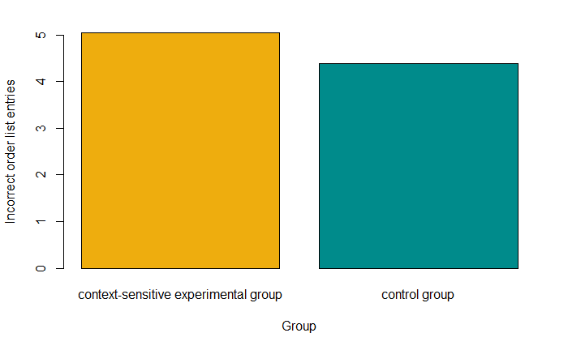

```r
# plot means between groups
barplot(mean_errors, col = c('darkgoldenrod2', 'darkcyan'), xlab = 'Group', ylab = 'Incorrect order list entries')
```

```
`fun.y` is deprecated. Use `fun` instead.
```

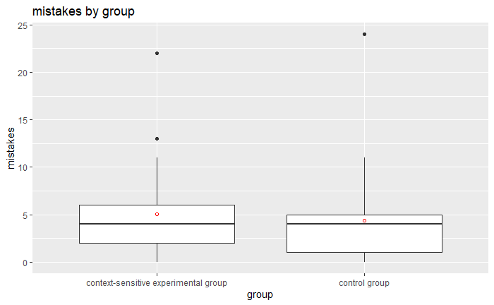

```r
# boxplots
ggplot(df_wide,aes(x = df_wide$'group', y=df_wide$mistakes_after_interruption) ) +
  geom_boxplot() +
  stat_summary(fun.y=mean,shape=1,col='red',geom='point') +
  labs(x="group",
       y = "mistakes",
       title="mistakes by group")
```

Exclude outliers

```r
tapply(df_wide$mistakes_after_interruption, df_wide$group, mean)
```

```
context-sensitive experimental group                        control group
                            5.047619                             4.380952
```

```r
tapply(df_wide$mistakes_after_interruption, df_wide$group, sd)
```

```
context-sensitive experimental group                        control group
                            5.171810                             5.563058
```

```r
exclude <- list(11, 26)
df_perf <- subset(df_wide, !(df_wide$partnr %in% exclude))
utest_mistakes_o <- wilcox.test(df_perf$mistakes_after_interruption~ df_perf$group, paired=FALSE, conf.int=FALSE)
```

```
kann bei Bindungen keinen exakten p-Wert Berechnen
```

```r
utest_mistakes_o
```

```
    Wilcoxon rank sum test with continuity correction

data:  df_perf$mistakes_after_interruption by df_perf$group
W = 228.5, p-value = 0.4448
alternative hypothesis: true location shift is not equal to 0
```

#### Ratio of mistakes to total amount of entries

Statistical analysis reveals no significant effect.

```r
## nr of mistakes / correct entries
df_wide <- transform(df_wide, perf = mistakes_after_interruption / entries_after_interruption)
df_perf <- transform(df_perf, perf = mistakes_after_interruption / entries_after_interruption)
mean_perf <- tapply(df_wide$perf, df_wide$group, mean)
```

##### test requirements for t-test

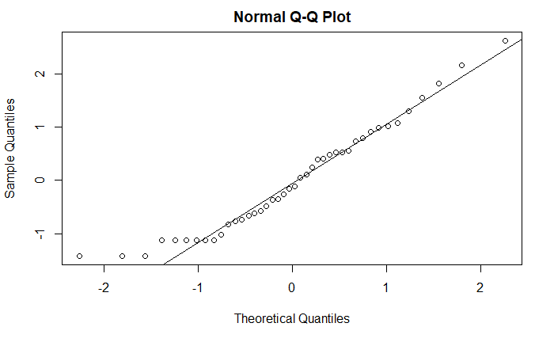

```r
## lineare model for correct_entries ~ groups
lm_perf <- lm(df_wide$perf~ df_wide$group)
# get studentized residuals
rstudent_perf <- rstudent(lm_perf)
qqnorm(rstudent_perf); qqline(rstudent_perf)
```

```r
# Run Shapiro-Wilk test
shapiro.test(x = rstudent_perf )
```

```
    Shapiro-Wilk normality test

data:  rstudent_perf
W = 0.95011, p-value = 0.06517
```

```r
## test homogenity of variances
var.test(perf~group, conf.level=0.95, data = df_wide, alternative=c("two.sided", "less", "greater"))
```

```
    F test to compare two variances

data:  perf by group
F = 0.97064, num df = 20, denom df = 20, p-value = 0.9475
alternative hypothesis: true ratio of variances is not equal to 1
95 percent confidence interval:
 0.3938516 2.3921297
sample estimates:
ratio of variances
         0.9706411
```

```r
# compare between groups
utest_perf <- wilcox.test(df_wide$perf~ df_wide$group, paired=FALSE, conf.int=FALSE)
```

```
kann bei Bindungen keinen exakten p-Wert Berechnen
```

```r
utest_perf
```

```
    Wilcoxon rank sum test with continuity correction

data:  df_wide$perf by df_wide$group
W = 253.5, p-value = 0.4119
alternative hypothesis: true location shift is not equal to 0
```

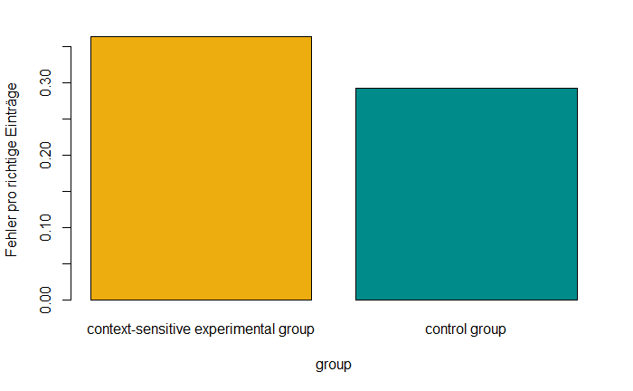

```r
# plot means between groups
barplot(mean_perf, col = c('darkgoldenrod2', 'darkcyan'), xlab = 'group', ylab = 'Fehler pro richtige Einträge')
```

```
`fun.y` is deprecated. Use `fun` instead.
```

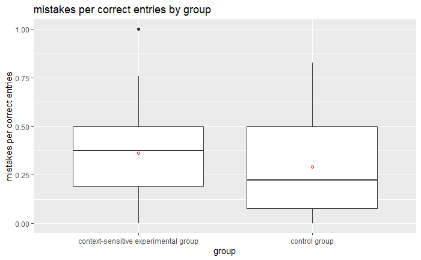

```r
# boxplots
ggplot(df_wide,aes(x = df_wide$'group', y=df_wide$perf) ) +
  geom_boxplot() +
  stat_summary(fun.y=mean,shape=1,col='red',geom='point') +
  labs(x="group",
       y = "mistakes per correct entries",
       title="mistakes per correct entries by group")
```

Analysis without participants 11 and 26

```r
utest_perf <- wilcox.test(df_perf$perf~ df_perf$group)
```

```
kann bei Bindungen keinen exakten p-Wert Berechnen
```

```r
utest_perf
```

```
    Wilcoxon rank sum test with continuity correction

data:  df_perf$perf by df_perf$group
W = 232.5, p-value = 0.3847
alternative hypothesis: true location shift is not equal to 0
```

### NASA-TLX

Does mental workload when working on the primary task differ between groups and over time?

As in the analysis of the complete dataset, the analysis reveals a significant main effect of trial but neither a main effect of group nor an interaction effect.

##### Check requirements for ANOVA

```r
# convert trial, group and subject number to factors
df_nasa$trial <- factor(df_nasa$trial, levels=c(0,1,2,3), labels=c('0','1','2','3'))
df_nasa$group <- factor(df_nasa$group)
df_nasa$partnr <- factor(df_nasa$partnr)
# compute split-plots anova
sp_nasa_anova <- aov(NASATLX ~ trial*group + Error(partnr/(trial)), data=df_nasa)
summary(sp_nasa_anova)
```

```
Error: partnr
          Df Sum Sq Mean Sq F value Pr(>F)
group      1   4.89   4.892   1.374  0.248
Residuals 40 142.45   3.561

Error: partnr:trial
             Df Sum Sq Mean Sq F value   Pr(>F)
trial         3   6.29  2.0977   6.883 0.000257 ***
trial:group   3   1.07  0.3563   1.169 0.324511
Residuals   120  36.57  0.3047
---
Signif. codes:  0 ‘***’ 0.001 ‘**’ 0.01 ‘*’ 0.05 ‘.’ 0.1 ‘ ’ 1
```

```r
## compute easy_anova as a check for split-plots anova
ez_nasa_anova = ezANOVA(
data = df_nasa
, dv = NASATLX
, wid = partnr
, within = trial
, between = group
, detailed = TRUE
)
anova_out(ez_nasa_anova)
```

```
$`--- ANOVA RESULTS     ------------------------------------`
       Effect       MSE df1 df2      F     p petasq getasq
1 (Intercept) 3.5612434   1  40 883.40 0.000   0.96   0.95
2       group 3.5612434   1  40   1.37 0.248   0.03   0.03
3       trial 0.3047399   3 120   6.88 0.000   0.15   0.03
4 group:trial 0.3047399   3 120   1.17 0.325   0.03   0.01

$`--- SPHERICITY TESTS  ------------------------------------`
       Effect p_Mauchly GGEpsilon  p_GG HFEpsilon  p_HF
1       trial     0.001     0.745 0.001     0.791 0.001
2 group:trial     0.001     0.745 0.319     0.791 0.320

$`--- FORMATTED RESULTS ------------------------------------`
       Effect                                    Text
1 (Intercept)  F(1, 40) = 883.40, p < .001, np2 = .96
2       group  F(1, 40) =   1.37, p = .248, np2 = .03
3       trial F(3, 120) =   6.88, p = .001, np2 = .15
4 group:trial F(3, 120) =   1.17, p = .319, np2 = .03

$`NOTE:`
[1] "p-values for the following effects were GG-adjusted (p_Mauchly <= 0.05): trial; group:trial. Reporting uncorrected degrees of freedom."
```

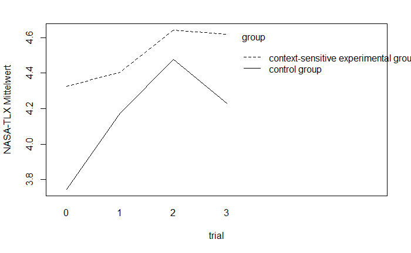

```r
# interaction
interaction.plot(df_nasa$`trial`, df_nasa$group, df_nasa$NASATLX, xlab = 'trial', ylab = 'NASA-TLX Mittelwert', trace.label = 'group', cex=1.3, pch=1, pt.cex = 1)
```

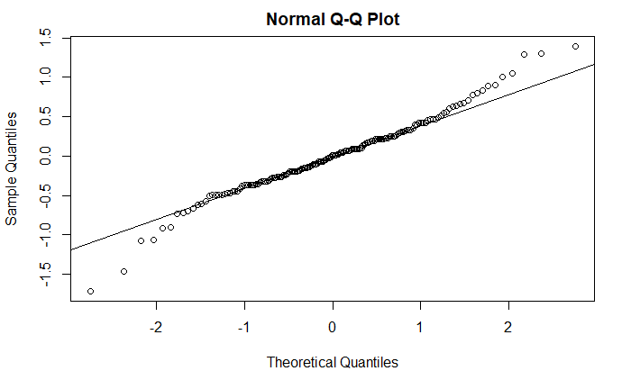

```r
# check normal distribution assumption by plotting residuals
aov_nasa.pr <- proj(sp_nasa_anova)
nasa_res <- aov_nasa.pr[[3]][, "Residuals"]
qqnorm(nasa_res); qqline(nasa_res)
```

```r
# Run Shapiro-Wilk test
shapiro.test(x = nasa_res )
```

```
    Shapiro-Wilk normality test

data:  nasa_res
W = 0.97813, p-value = 0.009325
```

```r
# run Levene test for homogeneity of variance across groups
leveneTest(df_nasa$NASATLX~df_nasa$group)
```

```
Levene's Test for Homogeneity of Variance (center = median)
       Df F value Pr(>F)
group   1  0.0384 0.8448
      166
```

QQplot of the residuals indicates that the assumption of normal distribution is not met –> compute robust ANOVA.

```r
## robust ANOVA
bwtrim(formula = NASATLX ~ group * trial, id = partnr, data = df_nasa)
```

```
Call:
bwtrim(formula = NASATLX ~ group * trial, id = partnr, data = df_nasa)
```

|  | value | df1 | df2 | p.value |
| --- | --- | --- | --- | --- |
| group | 1.9786 | 1 | 23.3669 | 0.1727 |
| trial | 3.6498 | 3 | 19.5285 | 0.0306 |
| group:trial | 1.5626 | 3 | 19.5285 | 0.2303 |

```
NA
```

### Resumption lags

Analysing distribution characteristics for raw, log-transformed and inverted resumption lags indicate that resumption speed (1/resumption lags) has the best distribution characteristics and shall therefore be used for the subsequent analysis. The analysis revealed significant main effects of group and trial, which confirms the results of the analysis which includes the context-free experimental group.

```r
# convert trial, group and subject number to factors
df_long$trial <- factor(df_long$trial, levels=c(1,2,3), labels=c('1','2','3'))
df_long$group <- factor(df_long$group)
df_long$partnr <- factor(df_long$partnr)
#transform the data
df_long$reslags_speed <- 1/df_long$resumption_lags
## compute split-plots anova for log-transformed resumption lags
reslags_speed_anova <- aov(reslags_speed ~ trial*group + Error(partnr/(trial)), data=df_long)
summary(reslags_speed_anova)
```

```
Error: partnr
          Df    Sum Sq   Mean Sq F value Pr(>F)
group      1 3.133e-08 3.133e-08   4.968 0.0315 *
Residuals 40 2.522e-07 6.306e-09
---
Signif. codes:  0 ‘***’ 0.001 ‘**’ 0.01 ‘*’ 0.05 ‘.’ 0.1 ‘ ’ 1

Error: partnr:trial
            Df    Sum Sq   Mean Sq F value   Pr(>F)
trial        2 6.320e-08 3.160e-08   7.556 0.000987 ***
trial:group  2 3.700e-09 1.832e-09   0.438 0.646876
Residuals   80 3.346e-07 4.183e-09
---
Signif. codes:  0 ‘***’ 0.001 ‘**’ 0.01 ‘*’ 0.05 ‘.’ 0.1 ‘ ’ 1
```

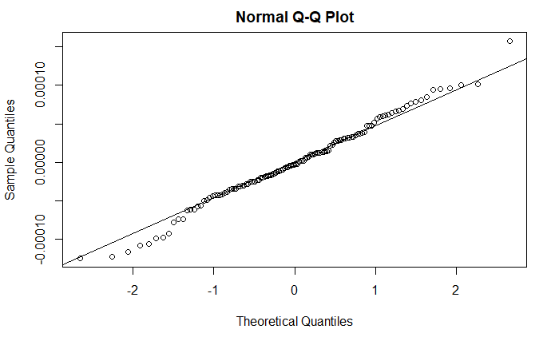

```r
# check normal distribution assumption by plotting residuals
aov_reslags_speed.pr <- proj(reslags_speed_anova)
reslagspeed_res <- aov_reslags_speed.pr[[3]][, "Residuals"]
qqnorm(reslagspeed_res); qqline(reslagspeed_res)
```

```r
# Run Shapiro-Wilk test
shapiro.test(x = reslagspeed_res )
```

```
    Shapiro-Wilk normality test

data:  reslagspeed_res
W = 0.99084, p-value = 0.576
```

```r
# run levene test for homogenity of variance across groups
leveneTest(df_long$reslags_speed~df_long$group)
```

```
Levene's Test for Homogeneity of Variance (center = median)
       Df F value Pr(>F)
group   1  2.1154 0.1483
      124
```

```
`fun.y` is deprecated. Use `fun` instead.
```

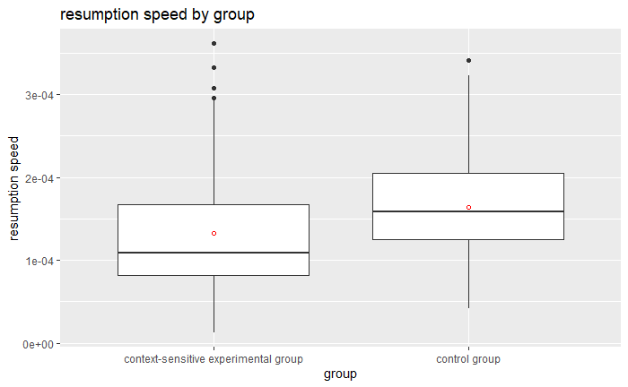

```r
# plot resumption speed
# Boxplot for resumption speed per group
ggplot(df_long,aes(x = group, y=reslags_speed) ) +
  geom_boxplot() +
  stat_summary(fun.y=mean,shape=1,col='red',geom='point') +
  labs(x="group",
       y = "resumption speed",
       title="resumption speed by group")
```

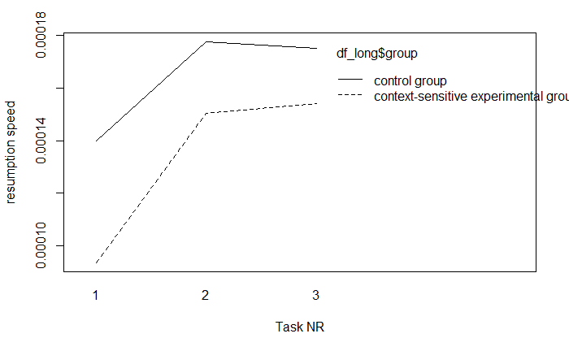

```r
# interaction plot
interaction.plot(df_long$trial, df_long$group, df_long$reslags_speed, xlab = 'Task NR', ylab = 'resumption speed')
```

Post-hoc analyis using paired t-tests

```r
pwc <- df_long%>%
  pairwise_t_test(
    reslags_speed ~ trial, paired = TRUE,
    p.adjust.method = "bonferroni"
    )
pwc
```

|  | .y. | group1 | group2 | n1 | n2 | statistic | df | p | p.adj | p.adj.signif |
| --- | --- | --- | --- | --- | --- | --- | --- | --- | --- | --- |
| 1 | reslags_speed | 1 | 2 | 42 | 42 | -3.83808375 | 41 | 0.000421 | 0.001 | ** |
| 2 | reslags_speed | 1 | 3 | 42 | 42 | -3.47436490 | 41 | 0.001000 | 0.004 | ** |
| 3 | reslags_speed | 2 | 3 | 42 | 42 | -0.04147629 | 41 | 0.967000 | 1.000 | ns |

### List input lags

Similar to the analysis of the full dataset, the analysis of list input lags between context-sensitive experimental group and control group yields no significant effects of group. Again, there is a trend that list input lags decrease over time which reaches significance in this case.

```r
## missing values per group
aggregate(df_long$list_input_lags, by= list(df_long$group),FUN=function(x) {sum(is.na(x))} )
```

| Group.1 | x |
| --- | --- |
| context-sensitive experimental group | 7 |
| control group | 6 |

```r
## missing values per test participant
aggregate(df_long$list_input_lags, by= list(df_long$partnr),FUN=function(x) {sum(is.na(x))} )
```

| Group.1 | x |
| --- | --- |
| 1 | 0 |
| 6 | 0 |
| 7 | 0 |
| 8 | 1 |
| 11 | 0 |
| 12 | 0 |
| 13 | 0 |
| 18 | 1 |
| 20 | 0 |
| 23 | 0 |

[output cut: 32 more lines]

```r
## substitute values with median
df_list_md <- df_long  %>% select(partnr, trial, group,list_input_lags)
list_exp <- df_list_md$list_input_lags[which(df_list_md$group == "context-sensitive experimental group")]
list_control <- df_list_md$list_input_lags[which(df_list_md$group == "control group")]
md_exp <- median(list_exp, na.rm = TRUE)
md_control <- median(list_control, na.rm = TRUE)
# replace NA's with median
df_list_md$list_input_lags[is.na(df_list_md$list_input_lags) & df_list_md$group == "context-sensitive experimental group"] <- md_exp
df_list_md$list_input_lags[is.na(df_list_md$list_input_lags) & df_list_md$group == "control group"] <- md_control
## check NA's
## missing values per group
aggregate(df_list_md$list_input_lags, by= list(df_list_md$group),FUN=function(x) {sum(is.na(x))} )
```

| Group.1 | x |
| --- | --- |
| context-sensitive experimental group | 0 |
| control group | 0 |

## Are there differences in how fast test participants make the the first order list entry after an interruption between groups and trials ?

```r
## compute split-plots anova for relative resumption lags
inputlag_anova <- aov(list_input_lags ~ trial*group + Error(partnr/(trial)), data=df_list_md)
summary(inputlag_anova)
```

```
Error: partnr
          Df    Sum Sq   Mean Sq F value Pr(>F)
group      1 9.390e+06 9.390e+06   0.002  0.964
Residuals 40 1.796e+11 4.489e+09

Error: partnr:trial
            Df    Sum Sq   Mean Sq F value Pr(>F)
trial        2 1.477e+10 7.383e+09   3.141 0.0486 *
trial:group  2 7.116e+07 3.558e+07   0.015 0.9850
Residuals   80 1.880e+11 2.351e+09
---
Signif. codes:  0 ‘***’ 0.001 ‘**’ 0.01 ‘*’ 0.05 ‘.’ 0.1 ‘ ’ 1
```

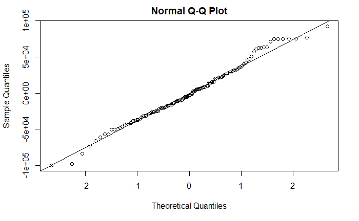

```r
# check normal distribution assumption by plotting residuals
aov_inputlag.pr <- proj(inputlag_anova)
inputlag_res <- aov_inputlag.pr[[3]][, "Residuals"]
qqnorm(inputlag_res); qqline(inputlag_res)
```

```r
# Run Shapiro-Wilk test
shapiro.test(x = inputlag_res )
```

```
    Shapiro-Wilk normality test

data:  inputlag_res
W = 0.98871, p-value = 0.3903
```

```r
# run levene test for homogeneity of variance across groups
leveneTest(df_list_md$list_input_lags~df_list_md$group)
```

```
Levene's Test for Homogeneity of Variance (center = median)
       Df F value Pr(>F)
group   1  0.0347 0.8526
      124
```

The tests indicate that the assumptions for ANOVA are met.

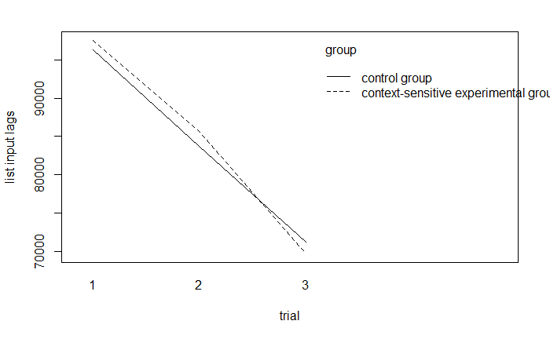

```r
# plot interaction
interaction.plot(df_list_md$`trial`, df_list_md$group, df_list_md$list_input_lags, xlab = 'trial', ylab = 'list input lags', trace.label = 'group', cex=1.3, pch=1, pt.cex = 1)
```

```
`fun.y` is deprecated. Use `fun` instead.
```

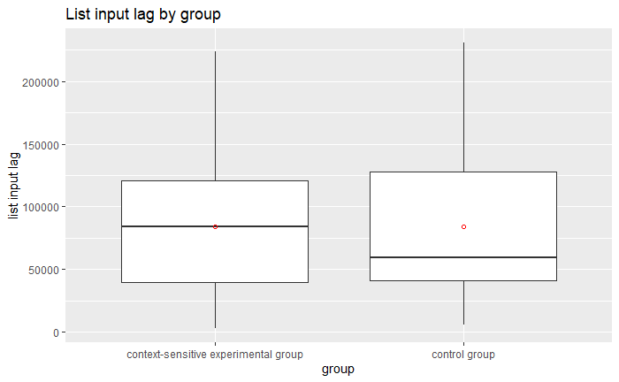

```r
# Boxplot for list input lag by group
ggplot(df_list_md,aes(x = df_list_md$'group', y=df_list_md$list_input_lags) ) +
  geom_boxplot() +
  stat_summary(fun.y=mean,shape=1,col='red',geom='point') +
  labs(x="group",
       y = "list input lag",
       title="List input lag by group")
```